# ECON 475 Final Project

Ramsey EL Lethy

2025-05-07

# Question 1. Use the dataset elec.csv that is available on Canvas. The variable elec is electricity retail sales to the residential sector in the United States in million of kilowatt hours. The sample is at monthly frequency and covers the period from January 1973 and December 2011. Define the training sample as all information available up to December 2010.

## (a) Let yt denote the log of electricity retail sales. Plot yt over time. Is there a trend?

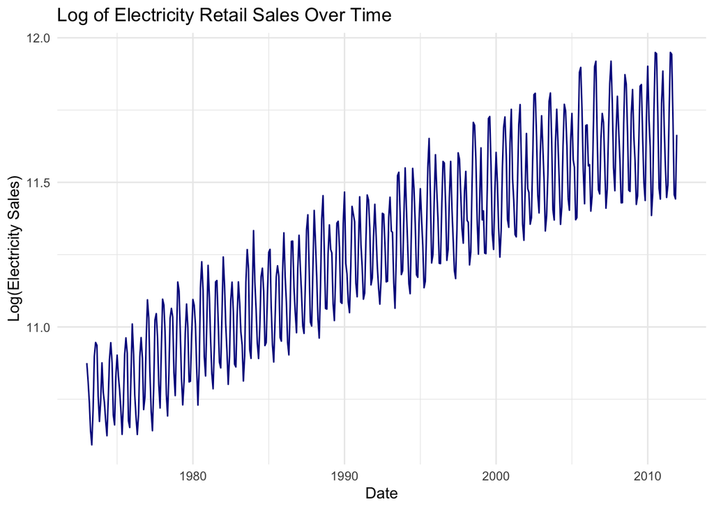

```r
library(ggplot2)
library(dplyr)
library(readr)

elec_data <- read_csv("elec.csv")

elec_data$log_elec <- log(elec_data$elec)

elec_data <- elec_data %>%
  mutate(
    date = as.Date(paste0(substr(date, 1, 4), "-", substr(date, 6, 7), "-01"))
  )


View(elec_data)

ggplot(elec_data, aes(x = date, y = log_elec)) +
  geom_line(color = "darkblue", group = 1) +
  labs(
    title = "Log of Electricity Retail Sales Over Time",
    x = "Date",
    y = "Log(Electricity Sales)"
  ) +
  theme_minimal()
```

It looks like the data has an upward trend over time.

## (b) Estimate a model with a linear and a quadratic trend. Which one would you choose? From now on, use the trend model you chose in part (b)

```r
elec_data <- elec_data %>%
  mutate(
    t = 1:n(),                # time trend
    t2 = t^2                 # quadratic term
  )

# Linear trend model
linear_model <- lm(log_elec ~ t, data = elec_data)

# Quadratic trend model
quad_model <- lm(log_elec ~ t + t2, data = elec_data)
```

```r
# Compare models
summary(linear_model)
```

```
##
## Call:
## lm(formula = log_elec ~ t, data = elec_data)
##
## Residuals:
##      Min       1Q   Median       3Q      Max
## -0.32867 -0.13043  0.00826  0.11619  0.30463
##
## Coefficients:
##              Estimate Std. Error t value Pr(>|t|)
## (Intercept) 1.078e+01  1.364e-02  790.33   <2e-16 ***
## t           2.086e-03  5.040e-05   41.38   <2e-16 ***
## ---
## Signif. codes:  0 '***' 0.001 '**' 0.01 '*' 0.05 '.' 0.1 ' ' 1
##
## Residual standard error: 0.1473 on 466 degrees of freedom
## Multiple R-squared:  0.7861, Adjusted R-squared:  0.7856
## F-statistic:  1712 on 1 and 466 DF,  p-value: < 2.2e-16
```

```r
summary(quad_model)
```

```
##
## Call:
## lm(formula = log_elec ~ t + t2, data = elec_data)
##
## Residuals:
##       Min        1Q    Median        3Q       Max
## -0.293908 -0.138007  0.004567  0.117660  0.309623
##
## Coefficients:
##               Estimate Std. Error t value Pr(>|t|)
## (Intercept)  1.073e+01  2.033e-02 527.934  < 2e-16 ***
## t            2.682e-03  2.002e-04  13.398  < 2e-16 ***
## t2          -1.272e-06  4.134e-07  -3.078  0.00221 **
## ---
## Signif. codes:  0 '***' 0.001 '**' 0.01 '*' 0.05 '.' 0.1 ' ' 1
##
## Residual standard error: 0.146 on 465 degrees of freedom
## Multiple R-squared:  0.7904, Adjusted R-squared:  0.7895
## F-statistic: 876.5 on 2 and 465 DF,  p-value: < 2.2e-16
```

```r
# AIC comparison
(AIC(linear_model, quad_model))
```

```
##              df       AIC
## linear_model  3 -460.5804
## quad_model    4 -468.0167
```

```r
(BIC(linear_model, quad_model))
```

```
##              df       BIC
## linear_model  3 -448.1350
## quad_model    4 -451.4229
```

We go with the quad model

## (c) Provide a plot of the correlogram (up to 25 lags) of the residuals of the model you chose in part (b). Is there any evidence of seasonal patterns in the correlogram? Explain your answer.

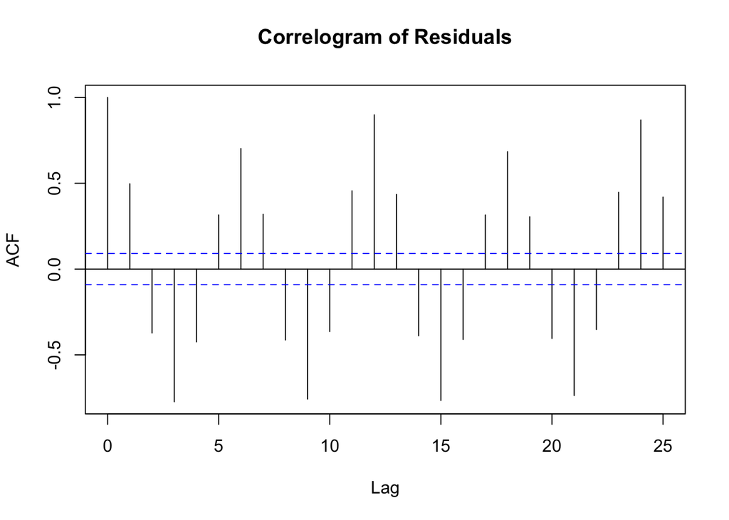

```r
resid_trend <- residuals(quad_model)  # or linear_model

# Plot ACF up to lag 25
acf(resid_trend, lag.max = 25, main = "Correlogram of Residuals")
```

There is definitely seasonality, notice how the positive and negatively related lags occur in even intervals, that the same relationship between even interval lags indicates seasonality in the data.

## (d) Estimate a model with a trend and a full set of dummy variables, and report the results.

```r
#will create a column indicating each month
elec_data$month <- factor(format(elec_data$date, "%m"))

# Create time trend variable
elec_data$trend <- 1:nrow(elec_data)

# Estimate model: log(elec) ~ trend + monthly dummies
seasonal_model <- lm(log(elec) ~ trend + month, data = elec_data)

# View summary results
summary(seasonal_model)
```

```
##
## Call:
## lm(formula = log(elec) ~ trend + month, data = elec_data)
##
## Residuals:
##       Min        1Q    Median        3Q       Max
## -0.167425 -0.033858 -0.000269  0.037078  0.137952
##
## Coefficients:
##               Estimate Std. Error  t value Pr(>|t|)
## (Intercept) 10.9558755  0.0100012 1095.458  < 2e-16 ***
## trend        0.0020890  0.0000192  108.799  < 2e-16 ***
## month02     -0.1234758  0.0127036   -9.720  < 2e-16 ***
## month03     -0.2122879  0.0127037  -16.711  < 2e-16 ***
## month04     -0.3482388  0.0127037  -27.412  < 2e-16 ***
## month05     -0.3724428  0.0127038  -29.317  < 2e-16 ***
## month06     -0.2013440  0.0127040  -15.849  < 2e-16 ***
## month07     -0.0021043  0.0127041   -0.166   0.8685
## month08      0.0218075  0.0127043    1.717   0.0867 .
## month09     -0.1060599  0.0127046   -8.348  8.4e-16 ***
## month10     -0.3046616  0.0127048  -23.980  < 2e-16 ***
## month11     -0.3374595  0.0127051  -26.561  < 2e-16 ***
## month12     -0.1345384  0.0127054  -10.589  < 2e-16 ***
## ---
## Signif. codes:  0 '***' 0.001 '**' 0.01 '*' 0.05 '.' 0.1 ' ' 1
##
## Residual standard error: 0.0561 on 455 degrees of freedom
## Multiple R-squared:  0.9697, Adjusted R-squared:  0.9689
## F-statistic:  1214 on 12 and 455 DF,  p-value: < 2.2e-16
```

```r
AIC(seasonal_model)
```

```
## [1] -1353.356
```

```r
BIC(seasonal_model)
```

```
## [1] -1295.278
```

Our model is much more fit to the data with a 96% model fit, it looks like most of that is apart of seasonality, the only non significant factor in our model is month 7 and 8.

## (e) Provide a plot of the correlogram (up to 25 lags) of the residuals of the model you chose in part (d). Is there any evidence of cyclical component or serial correlation in the residuals? Explain your answer.

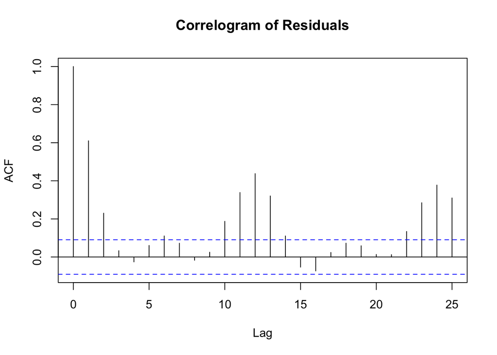

```r
resid_trend_seasonal <- residuals(seasonal_model)

acf(resid_trend_seasonal, lag.max = 25, main = "Correlogram of Residuals")
```

it looks like after plotting seasonality and trends, there is still some correlated lags, ideally, if we captured all the effects of the model, the plot of the residuals should just be a white noise process. But this correlogram still has a pretty significant relationship between the lags, which tells us that there is some cyclical component to be included in our model.

## (f) Estimate an ARMA(p,q) model with p = 0, 1, 2, 3 and q = 0, 1, 2, 3, except for p = q = 0. Report the values of the BICs. Based on the correlogram and values of the BIC, which model would you choose? Explain your answer.

```r
log_ts <- ts(elec_data$log_elec, start = c(1973, 1), frequency = 12)


bic_results <- data.frame(p = integer(), q = integer(), BIC = numeric())

bic_results
```

```
## [1] p   q   BIC
## <0 rows> (or 0-length row.names)
```

```r
# Fit ARMA models and store BIC
for (p in 0:3) {
  for (q in 0:3) {
    if (p == 0 & q == 0) next
    model <- tryCatch(
      arima(log_ts, order = c(p, 0, q)),
      error = function(e) NULL
    )
    if (!is.null(model)) {
      #if we got a non null value for arma(p,0,q), store its bic into the df
      bic_results <- rbind(bic_results, data.frame(p = p, q = q, BIC = BIC(model)))
    }
  }
}
bic_results
```

```
##    p q        BIC
## 1  0 1  -231.4827
## 2  0 2  -524.0337
## 3  0 3  -613.0865
## 4  1 0  -477.9596
## 5  1 1  -666.3832
## 6  1 2  -683.0051
## 7  1 3  -822.2391
## 8  2 0  -572.7006
## 9  2 1  -670.3474
## 10 2 2  -677.6677
## 11 2 3  -694.4306
## 12 3 0  -823.4755
## 13 3 1 -1044.4332
## 14 3 2 -1024.7070
## 15 3 3 -1126.2405
```

```r
# sort the results
bic_results <- bic_results[order(bic_results$BIC), ]
print(bic_results)
```

```
##    p q        BIC
## 15 3 3 -1126.2405
## 13 3 1 -1044.4332
## 14 3 2 -1024.7070
## 12 3 0  -823.4755
## 7  1 3  -822.2391
## 11 2 3  -694.4306
## 6  1 2  -683.0051
## 10 2 2  -677.6677
## 9  2 1  -670.3474
## 5  1 1  -666.3832
## 3  0 3  -613.0865
## 8  2 0  -572.7006
## 2  0 2  -524.0337
## 4  1 0  -477.9596
## 1  0 1  -231.4827
```

It looks like the Arima with the lowest BIC would be with 3 lags of yt and 3 lags of the error, so we will choose an ARMA(3,0,3) process for the rest of this section

## (g) Report the estimation results of the model you choose in part (f). In addition, provide a plot and the correlogram (up to 25 lags) of the residuals of the model. Is there any evidence of cyclical component or serial correlation? Explain your answer

```r
library(stats)
log_ts <- ts(elec_data$log_elec, start = c(1973, 1), frequency = 12)

# Fit ARMA(3,0,3) model
arma_model <- arima(log_ts, order = c(3, 0, 3))

arma_model
```

```
##
## Call:
## arima(x = log_ts, order = c(3, 0, 3))
##
## Coefficients:
##          ar1      ar2     ar3      ma1     ma2     ma3  intercept
##       1.9769  -1.9733  0.9763  -0.9262  0.7773  0.1392    11.2648
## s.e.  0.0128   0.0144  0.0132   0.0845  0.1173  0.0971     0.1419
##
## sigma^2 estimated as 0.004656:  log likelihood = 587.71,  aic = -1159.43
```

here is our very beautiful ARMA(3,3) summary on the log of electricity sales, it looks like each auto regressive lag is alternating in sign effect, but absolute magnitude of effect is decreasing, while there isn’t a particular trend in the direction of the effect, but it also looks like the absolute magnitude is decreasing.

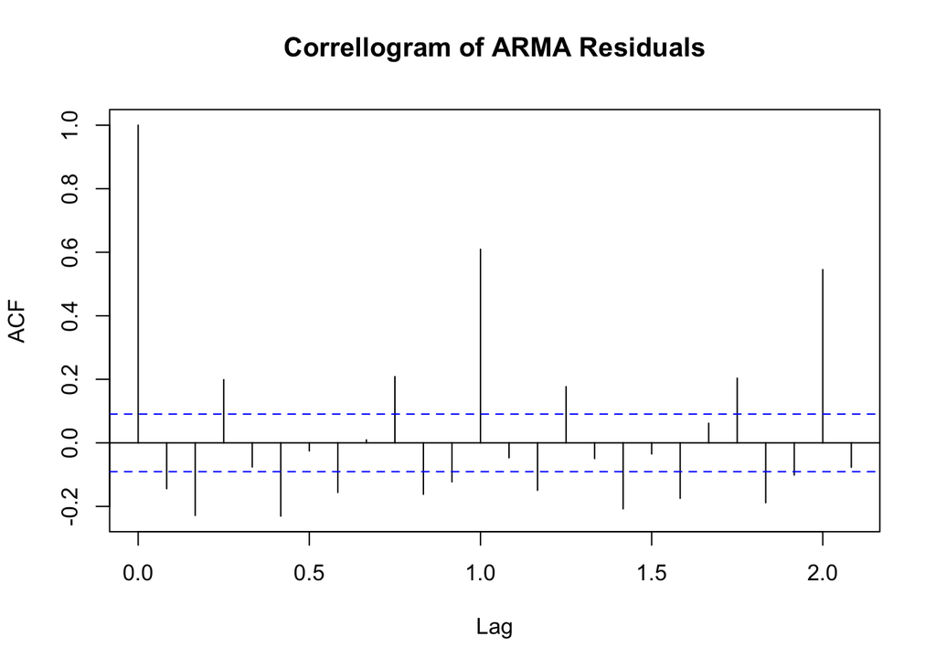

```r
residual_arma <- residuals(arma_model)

acf <- acf(residual_arma, lag.max = 25, main = "Correllogram of ARMA Residuals")
```

It looks like we’ve done a better job at making our residuals follow a white noise process, there is some high correlation at lag 12 and lag 24, but most of the residuals do fall above the threshold of a white noise process, so it does suggest that the residuals could be serially correlated.

## (h) Use the model you chose in part (f) to forecast the log of the electricity retail sales for the year of 2011, and compute its 95% forecast interval as well. Plot your point and interval forecasts together with the actual data for the period from 2008 to 2011

[figure not shown]

```r
library(ggplot2)
library(forecast)
# Forecast for 12 months ahead (2011)
arma_forecast <- forecast(arma_model, h = 12, level = 95)

actual_ts <- window(log_ts, start = c(2008, 1), end = c(2011, 12))

# forecast with confidence intervals and actual data
autoplot(arma_forecast) +
  autolayer(actual_ts, series = "Actual", color = "orange") +
  labs(
    title = "Forecast of Log Electricity Sales (2011)",
    x = "Year",
    y = "Log Electricity Sales"
  ) +
  theme_minimal() +
  # <-- adjust this range as needed
  guides(colour = guide_legend(title = "Series"))
```

# Question 2. Use the dataset wti_oil_price.csv that is available on Canvas. The variable oil_price is the seasonally-adjusted crude oil prices and is on dollars per barrel. The sample is at monthly frequency and covers the period from January 1986 to October 2024. Define the training sample as all information available up to 2022.

## (a) Let yt denote the seasonally-adjusted oil prices. Plot yt over time. Does the data look stationary?

```r
oil_data <- read_csv("wti_oil_price.csv")

oil_data
```

```
## # A tibble: 466 × 3
##     ...1 date       oil_price
##    <dbl> <date>         <dbl>
##  1     1 1986-01-01      22.4
##  2     2 1986-02-01      15.3
##  3     3 1986-03-01      12.9
##  4     4 1986-04-01      12.4
##  5     5 1986-05-01      14.8
##  6     6 1986-06-01      13.2
##  7     7 1986-07-01      11.7
##  8     8 1986-08-01      15.0
##  9     9 1986-09-01      15.2
## 10    10 1986-10-01      15.1
## # ℹ 456 more rows
```

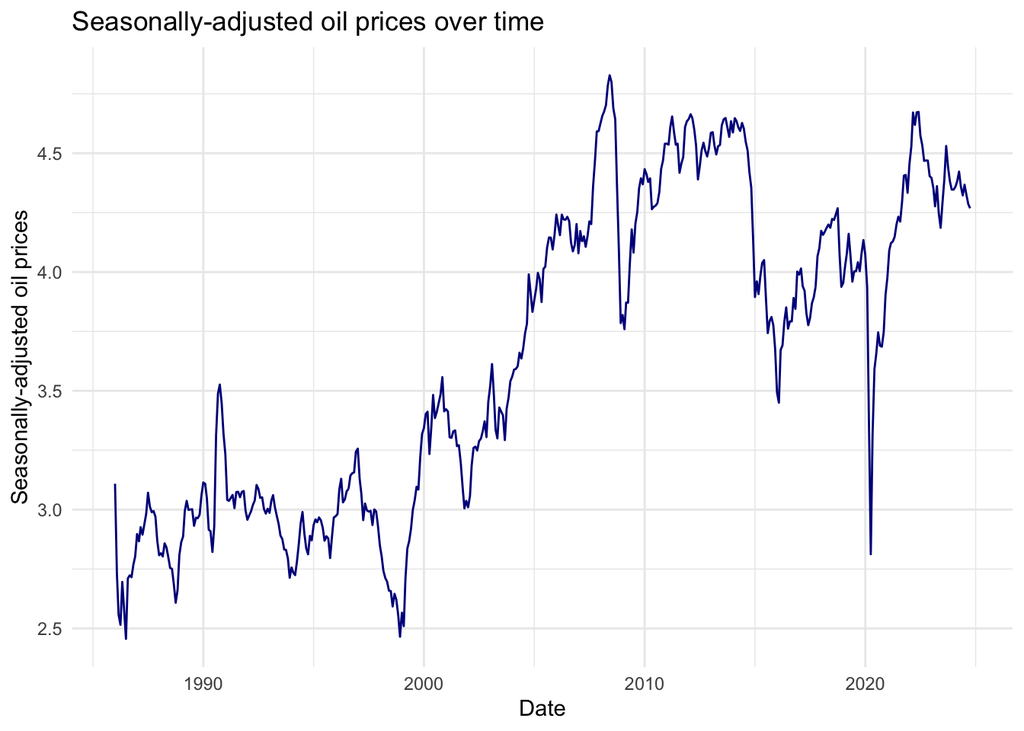

```r
ggplot(oil_data, aes(x = date, y = log(oil_price))) +
  geom_line(color = "darkblue", group = 1) +
  labs(
    title = "Seasonally-adjusted oil prices over time",
    x = "Date",
    y = "Seasonally-adjusted oil prices"
  ) +
  theme_minimal()
```

At a first glance, it looks like this process isn’t really stationary, its good that there doesnt seem to be a consistent linear trend, but the variance shocks seem to be very random. Maybe this suggest that this process doesn’t have very strong components, or there exists a unit root

## (b) Plot both the ACF and the PACF of yt. What does the correlogram suggest about yt?

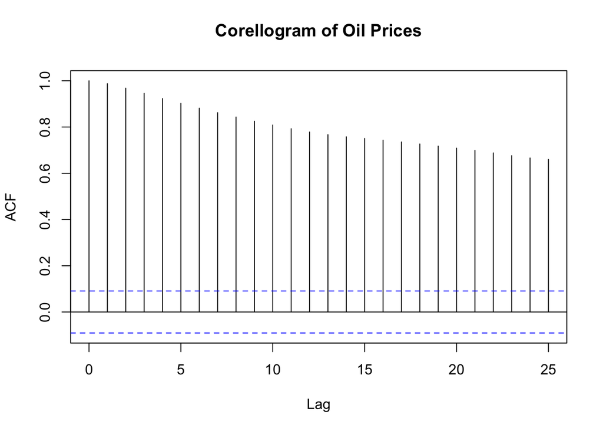

```r
acf <- acf(oil_data$oil_price, lag.max = 25, main = "Corellogram of Oil Prices")
```

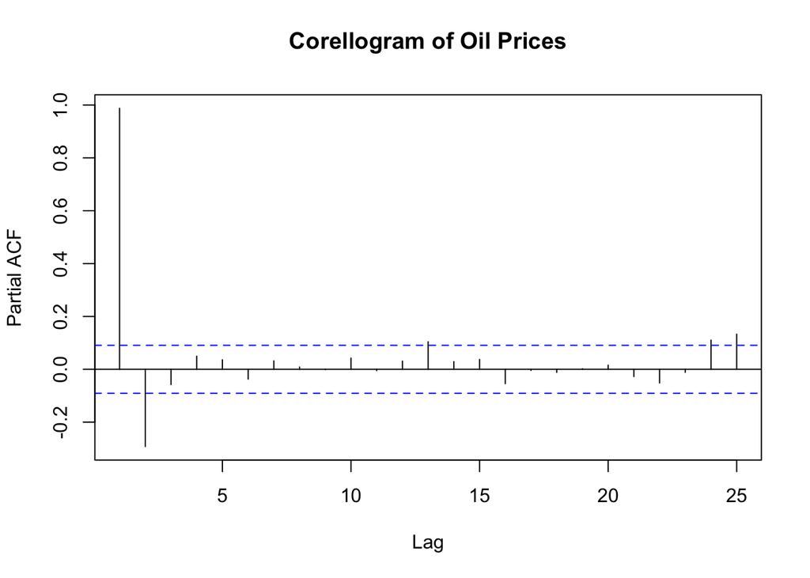

```r
pacf <- pacf(oil_data$oil_price, lag.max = 25, main = "Corellogram of Oil Prices")
```

## (c) To support your answer in the previous question, perform a Dickey-Fuller test for the presence of a unit root. More specifically, run a regression for each of the following specifications

1. Baseline model. ∆yt = φyt−1 + εt
2. Model with a drift. ∆yt = δ + φyt−1 + εt
3. Model with a drift and a trend ∆yt = δ + βt + φyt−1 + εt

For each specification, compute the Dickey-Fuller test statistic.

```r
oil_data$log_oil = log(oil_data$oil_price)
attach(oil_data)
oil_data$log_oil = log(oil_price)
oil_data$diff_oil = c(NA, diff(log_oil))
lag_log_oil = lag(log_oil)
t = 1:nrow(oil_data)


df_model1 <- lm(diff_oil ~ 0 + lag_log_oil, data = oil_data)
summary(df_model1)
```

```
##
## Call:
## lm(formula = diff_oil ~ 0 + lag_log_oil, data = oil_data)
##
## Residuals:
##      Min       1Q   Median       3Q      Max
## -0.56363 -0.04375  0.00401  0.05101  0.50519
##
## Coefficients:
##              Estimate Std. Error t value Pr(>|t|)
## lag_log_oil 0.0003628  0.0011460   0.317    0.752
##
## Residual standard error: 0.09173 on 464 degrees of freedom
##   (1 observation deleted due to missingness)
## Multiple R-squared:  0.000216,   Adjusted R-squared:  -0.001939
## F-statistic: 0.1002 on 1 and 464 DF,  p-value: 0.7517
```

```r
df_model2 <- lm(diff_oil ~ lag_log_oil, data = oil_data)
summary(df_model2)
```

```
##
## Call:
## lm(formula = diff_oil ~ lag_log_oil, data = oil_data)
##
## Residuals:
##      Min       1Q   Median       3Q      Max
## -0.56636 -0.04484  0.00433  0.04828  0.49573
##
## Coefficients:
##              Estimate Std. Error t value Pr(>|t|)
## (Intercept)  0.037175   0.023960   1.552    0.121
## lag_log_oil -0.009493   0.006455  -1.471    0.142
##
## Residual standard error: 0.09159 on 463 degrees of freedom
##   (1 observation deleted due to missingness)
## Multiple R-squared:  0.00465,    Adjusted R-squared:  0.0025
## F-statistic: 2.163 on 1 and 463 DF,  p-value: 0.142
```

```r
df_model3 <- lm(diff_oil ~ lag_log_oil + t, data = oil_data)
summary(df_model3)
```

```
##
## Call:
## lm(formula = diff_oil ~ lag_log_oil + t, data = oil_data)
##
## Residuals:
##      Min       1Q   Median       3Q      Max
## -0.59354 -0.04443  0.00485  0.04996  0.45709
##
## Coefficients:
##               Estimate Std. Error t value Pr(>|t|)
## (Intercept)  8.265e-02  3.152e-02   2.622  0.00904 **
## lag_log_oil -2.969e-02  1.118e-02  -2.655  0.00820 **
## t            1.210e-04  5.482e-05   2.207  0.02779 *
## ---
## Signif. codes:  0 '***' 0.001 '**' 0.01 '*' 0.05 '.' 0.1 ' ' 1
##
## Residual standard error: 0.09121 on 462 degrees of freedom
##   (1 observation deleted due to missingness)
## Multiple R-squared:  0.01504,    Adjusted R-squared:  0.01077
## F-statistic: 3.527 on 2 and 462 DF,  p-value: 0.0302
```

In both models 1 and 2, we see that the dicky fuller test gave us an insignificant outcome, meaning that there is not ennough evidence to reject a unit root.

the last model has very slim margins of significance which probably isnt enough to reject the null hypothesis that there is a unit root too.

## (d) Use the adf.test in R to perform the Dickey-Fuller test and compare your results with part (c). Do you obtain the same test statistic? Based on the p-values, do you have evidence to reject the null hypothesis of a unit root? From now on, consider the data in differences given by ∆yt = yt − yt−1.

```r
library(tseries)
dicky_fuller <- adf.test(log_oil, k = 0)
print(dicky_fuller)
```

```
##
##  Augmented Dickey-Fuller Test
##
## data:  log_oil
## Dickey-Fuller = -2.6551, Lag order = 0, p-value = 0.3009
## alternative hypothesis: stationary
```

adf gave us a p-value of 0.3009 which is a lot greater than the rejection baseline of 0.05 so we fail to reject the null hypothesis that the log of oil prices has a unit root (not stationary).

##(e) Compute both the correlogram and the Augmented Dickey-Fuller test for the data in differences. What does the results suggest about ∆yt?

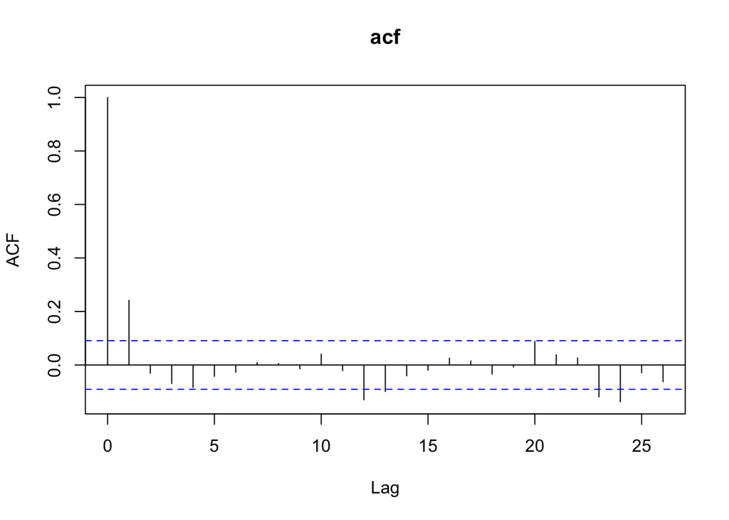

```r
attach(oil_data)
diff_series <- na.omit(diff_oil)
acf <- acf(diff_series, main = "acf")
```

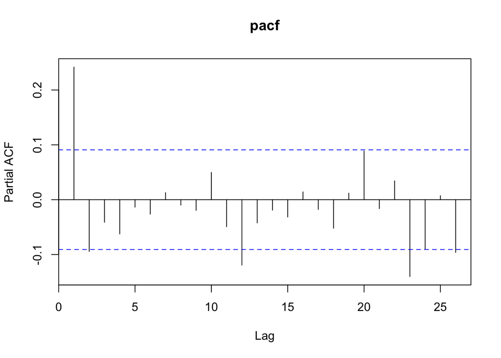

```r
pact <- pacf(diff_series, main = "pacf")
```

Now there looks like a sharp cutoff in the ACF after lag 1, as well as in the PACF, this suggests that there is some sort of stationarity, potentially yt in differences follows an AR(1) process.

## (f) Estimate an ARMA(p,q) model with p = 0, 1, 2, 3 and q = 0, 1, 2, 3 for ∆yt. Report the values of the BICs. Based on the correlogram and values of the BICs, which model would you choose? Explain your answer.

```r
library(forecast)

arma_bic_results <- data.frame(p = integer(), q = integer(), BIC = numeric())

for (p in 0:3) {
  for (q in 0:3) {
    if (p == 0 && q == 0) next  # Skip (0,0)

    model <- tryCatch(
      Arima(diff_series, order = c(p, 0, q), include.mean = FALSE),
      error = function(e) NULL
    )

    if (!is.null(model)) {
      bic_val <- BIC(model)
      arma_bic_results <- rbind(
        arma_bic_results,
        data.frame(p = p, q = q, BIC = bic_val)
      )
    }
  }
}

# sort by BIC
arma_bic_results <- arma_bic_results[order(arma_bic_results$BIC), ]
print(arma_bic_results)
```

```
##    p q       BIC
## 1  0 1 -923.1649
## 4  1 0 -919.9593
## 8  2 0 -917.8952
## 2  0 2 -917.0425
## 5  1 1 -917.0379
## 6  1 2 -916.5218
## 9  2 1 -915.9977
## 12 3 0 -912.5393
## 3  0 3 -911.3407
## 13 3 1 -910.9595
## 10 2 2 -910.9422
## 7  1 3 -910.8966
## 14 3 2 -904.9376
## 11 2 3 -904.7868
## 15 3 3 -898.8573
```

It looks like this process has a lowest BIC with an AR of 0 and a moving average process of 1. This aligned with the intuition of the Corellogram where only lag 1 has any sort of significant impact.

## (g) Use the model you chose in part (f) to forecast changes in oil prices for the years of 2023 and 2024, and compute its 95% forecast interval as well. Plot your point and interval forecasts together with the actual data for the period from 2016 to 2024.

```r
diff_series <- ts(diff_series, start = c(1986, 2), frequency = 12)
train_diff <- window(diff_series, end = c(2022, 12))  # training data

start(diff_series)
```

```
## [1] 1986    2
```

```r
end(diff_series)
```

```
## [1] 2024   10
```

```r
ma_model <- Arima(train_diff, order = c(0, 0, 1))

ma_model
```

```
## Series: train_diff
## ARIMA(0,0,1) with non-zero mean
##
## Coefficients:
##          ma1    mean
##       0.2770  0.0026
## s.e.  0.0462  0.0054
##
## sigma^2 = 0.008028:  log likelihood = 441.07
## AIC=-876.14   AICc=-876.09   BIC=-863.86
```

```r
#  24 months ahead
ma_forecast <- forecast(ma_model, h = 24, level = 95)

ma_forecast
```

```
##          Point Forecast      Lo 95     Hi 95
## Jan 2023   -0.015640563 -0.1912508 0.1599696
## Feb 2023    0.002636933 -0.1795856 0.1848594
## Mar 2023    0.002636933 -0.1795856 0.1848594
## Apr 2023    0.002636933 -0.1795856 0.1848594
## May 2023    0.002636933 -0.1795856 0.1848594
## Jun 2023    0.002636933 -0.1795856 0.1848594
## Jul 2023    0.002636933 -0.1795856 0.1848594
## Aug 2023    0.002636933 -0.1795856 0.1848594
## Sep 2023    0.002636933 -0.1795856 0.1848594
## Oct 2023    0.002636933 -0.1795856 0.1848594
## Nov 2023    0.002636933 -0.1795856 0.1848594
## Dec 2023    0.002636933 -0.1795856 0.1848594
## Jan 2024    0.002636933 -0.1795856 0.1848594
## Feb 2024    0.002636933 -0.1795856 0.1848594
## Mar 2024    0.002636933 -0.1795856 0.1848594
## Apr 2024    0.002636933 -0.1795856 0.1848594
## May 2024    0.002636933 -0.1795856 0.1848594
## Jun 2024    0.002636933 -0.1795856 0.1848594
## Jul 2024    0.002636933 -0.1795856 0.1848594
## Aug 2024    0.002636933 -0.1795856 0.1848594
## Sep 2024    0.002636933 -0.1795856 0.1848594
## Oct 2024    0.002636933 -0.1795856 0.1848594
## Nov 2024    0.002636933 -0.1795856 0.1848594
## Dec 2024    0.002636933 -0.1795856 0.1848594
```

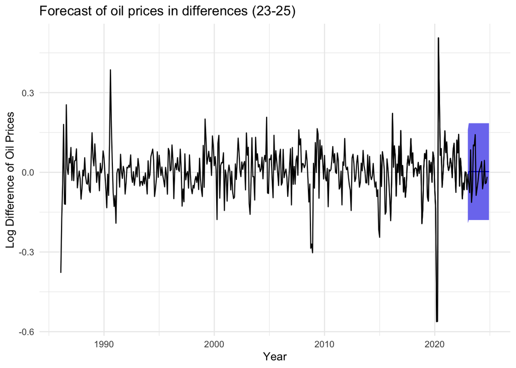

```r
diff_series_window <- window(diff_series, start = c(2016, 1))

autoplot(ma_forecast) +
  autolayer(diff_series_window, series = "Actual Changes", color = "black") +
  labs(title = "Forecast of oil prices in differences (23-25)", x = "Year",
    y = "Log Difference of Oil Prices"
  ) +
  theme_minimal() +
  guides(color = guide_legend(title = "Series"))
```